# Chapter 10 - Linear models: exercises

Author

Prof. Richard Wilkinson

## Question 1

Show that the ridge regression estimator of $\boldsymbol \beta$ is
$$\hat{\boldsymbol \beta}^{ridge} = (\mathbf X^\top \mathbf X+ \lambda\mathbf I_p)^{-1}\mathbf X^\top \mathbf y.$$

**Solution**

$$\hat{\boldsymbol \beta}^{ridge} = \arg \min_{\boldsymbol \beta} S(\boldsymbol \beta)$$

where
$$S(\boldsymbol \beta)=||\mathbf y- \mathbf X\boldsymbol \beta||^2_2+\lambda||\boldsymbol \beta||_2^2 .$$

Differentiating with respect to $\boldsymbol \beta$ we find that

$$\frac{\mathrm dS}{\mathrm d\boldsymbol \beta} = -2\mathbf X^\top (\mathbf y- \mathbf X\boldsymbol \beta) +2\lambda \boldsymbol \beta$$

The derivative is zero at the minima, giving the equation
$$0=-2\mathbf X^\top (\mathbf y- \mathbf X\hat{\boldsymbol \beta}^{ridge}) +2\lambda \hat{\boldsymbol \beta}^{ridge}$$
Rearranging gives
$$(\mathbf X^\top \mathbf X+ \lambda \mathbf I)\hat{\boldsymbol \beta}^{ridge} = \mathbf X^\top \mathbf y,$$
which can be rearranged to give
$$\hat{\boldsymbol \beta}^{ridge} = (\mathbf X^\top \mathbf X+ \lambda\mathbf I)^{-1}\mathbf X^\top \mathbf y$$
when the inverse exists.

Prove that the inverse exists if $\lambda > 0$.

**Solution**

$$\mathbf w^\top (\mathbf X^\top \mathbf X+ \lambda \mathbf I)\mathbf w= (\mathbf X\mathbf w)^\top(\mathbf X\mathbf w)+\lambda \mathbf w^\top \mathbf w= ||\mathbf X\mathbf w||_2^2 + \lambda ||\mathbf w||_2^2>0.$$

Thus $(\mathbf X^\top \mathbf X+ \lambda \mathbf I)$ is positive definite, and thus $(\mathbf X^\top \mathbf X+ \lambda \mathbf I)^{-1}$ exists. Note that if $\lambda=0$ (which is the case for OLS), then we can have $\mathbf X\mathbf w= \boldsymbol 0$.

Finally, prove that the estimator can rewritten as
$$\hat{\boldsymbol \beta}^{ridge} = \mathbf X^\top(\mathbf X\mathbf X^\top + \lambda\mathbf I_n)^{-1} \mathbf y.$$
When might this be useful?

**Solution**

Note that

$$(\mathbf X^\top \mathbf X+ \lambda \mathbf I_p)\mathbf X^\top = \mathbf X^\top (\mathbf X\mathbf X^\top + \lambda \mathbf I_n)$$
Thus if we left multiply by $(\mathbf X^\top \mathbf X+ \lambda \mathbf I_p)^{-1}$ and right multiply by $(\mathbf X\mathbf X^\top + \lambda \mathbf I_n)^{-1}$, we get
$$\mathbf X^\top (\mathbf X\mathbf X^\top + \lambda \mathbf I_n)^{-1}= (\mathbf X^\top \mathbf X+ \lambda \mathbf I_p)^{-1}\mathbf X^\top$$
and the result follows.

Note that $\mathbf X\mathbf X^\top$ is the $n \times n$ Gram matrix we saw in previous chapters. This *dual* form of the ridge regression estimator hints at the way many statistical procedures can be *kernelized* to create powerful non-linear methods that form the basis of much of modern machine learning.

Note that the first expression involves the inverse of a $p\times p$ matrix, whereas the second involves an $n \times n$ matrix. Thus the second form will be computationally cheaper when $n<p$.

## Question 2

Let
$$\hat{\boldsymbol \beta}_\lambda=\arg \min_{\boldsymbol \beta} ||\mathbf y-\mathbf X\boldsymbol \beta||_2^2+\lambda ||\boldsymbol \beta||$$
Prove that
$$||\hat{\boldsymbol \beta}_\lambda|| \leq ||\hat{\boldsymbol \beta}^{ols}||.$$
Note that we can prove this for a general norm $||\cdot||$, not just the $L_2$ norm.

**Solution**

By definition,
$$||\mathbf y- \mathbf X\hat{\boldsymbol \beta}^{ols}||_2^2\leq ||\mathbf y- \mathbf X\hat{\boldsymbol \beta}_\lambda||_2^2$$
If
$$||\hat{\boldsymbol \beta}^{ols}||< ||\hat{\boldsymbol \beta}_\lambda||$$
then it follows that
$$||\mathbf y-\mathbf X\hat{\boldsymbol \beta}^{ols}||_2^2+\lambda ||\hat{\boldsymbol \beta}^{ols}||<||\mathbf y-\mathbf X\hat{\boldsymbol \beta}_\lambda||_2^2+\lambda ||\hat{\boldsymbol \beta}_\lambda||$$
which is a contradiction as $\hat{\boldsymbol \beta}_\lambda$ is the minimizer of the RHS. Thus we must have
$$||\hat{\boldsymbol \beta}^{ols}||\geq ||\hat{\boldsymbol \beta}_\lambda||.$$

## Question 3

For the normal linear model
$$\mathbf y= \mathbf X\boldsymbol \beta+ N(\boldsymbol 0, \sigma^2 \mathbf I)$$
show that
$$\begin{align}
{\mathbb{V}\operatorname{ar}}(\hat{\boldsymbol \beta}^{ols}) &= \sigma^2 (\mathbf X^\top \mathbf X)^{-1}\\
&= \sigma^2\sum_{i=1}^p \frac{\mathbf v_i \mathbf v_i^\top}{\lambda_i}
\end{align}$$
where $\lambda_i$ are the eigenvalues of $\mathbf X^\top \mathbf X$, and $\mathbf v_i$ the corresponding unit eigenvectors.

**Solution**

$$\hat{\boldsymbol \beta}^{ols} = (\mathbf X^\top \mathbf X)^{-1}\mathbf X^\top \mathbf y$$
and thus

$$\begin{align}
{\mathbb{V}\operatorname{ar}}(\hat{\boldsymbol \beta}^{ols}) &= {\mathbb{V}\operatorname{ar}}((\mathbf X^\top \mathbf X)^{-1}\mathbf X^\top \mathbf y)\\
&= (\mathbf X^\top \mathbf X)^{-1}\mathbf X^\top {\mathbb{V}\operatorname{ar}}(\mathbf y) ((\mathbf X^\top \mathbf X)^{-1}\mathbf X^\top)^\top\\
&=\sigma^2 (\mathbf X^\top \mathbf X)^{-1}\mathbf X^\top \mathbf X(\mathbf X^\top \mathbf X)^{-1}\\
&= \sigma^2 (\mathbf X^\top \mathbf X)^{-1}.
\end{align}$$
The spectral decomposition of $\mathbf X^\top \mathbf X$ is $\mathbf V\boldsymbol \Lambda\mathbf V^\top$ where $\boldsymbol \Lambda= \operatorname{diag}(\lambda_1, \ldots, \lambda_p)$ and thus $(\mathbf X^\top \mathbf X)^{-1}=\mathbf V\boldsymbol \Lambda^{-1} \mathbf V^\top = \sum_{i=1}^p \frac{\mathbf v_i \mathbf v_i^\top}{\lambda_i}$ and the result follows.

This expression really highlights why OLS can lead to highly variable estimates. We know that the eigenvalues of $\mathbf X^\top \mathbf X$ must all be positive if the matrix is invertible, but if some of the eigenvalues are very close to zero, then the variance of the estimator may be very large.

If $\hat{\boldsymbol \beta}_k$ is the PCR estimator based on the first $k$ principal components, show that
$${\mathbb{V}\operatorname{ar}}(\hat{\boldsymbol \beta}_k) = \sigma^2 \sum_{i=1}^k \frac{\mathbf v_i \mathbf v_i^\top}{\lambda_i}.$$

**Solution**

The PCR estimator based on the first $k$ principal components is

$$\hat{\boldsymbol \beta}_k = \mathbf V_k \boldsymbol{\Sigma}_k^{-1}\mathbf U_k^\top \mathbf y$$
and so
$$\begin{align}
{\mathbb{V}\operatorname{ar}}(\hat{\boldsymbol \beta}_k ) &= \sigma^2 \mathbf V_k \boldsymbol{\Sigma}_k^{-1}\mathbf U_k^\top \mathbf U_k \boldsymbol{\Sigma}_k^{-1} \mathbf V_k^\top\\
&=\sigma^2 \mathbf V_k \boldsymbol{\Sigma}_k^{-2} \mathbf V_k^\top
\end{align}$$
as $\mathbf U_k^\top \mathbf U_k = \mathbf I$. Here $\mathbf V_k$ is the matrix of first $k$ right singular vectors of $\mathbf X$, which are the same as the eigenvectors of $\mathbf X^\top\mathbf X$. $\boldsymbol{\Sigma}^2$ is the diagonal matrix of singular values squared, which are the same as the eigenvalues of $\mathbf X^\top\mathbf X$. Thus
$$\begin{align}
{\mathbb{V}\operatorname{ar}}(\hat{\boldsymbol \beta}_k ) &= \sigma^2 \mathbf V_k \boldsymbol{\Sigma}_k^{-2} \mathbf V_k^\top\\
&=\sigma^2 \sum_{i=1}^k \frac{\mathbf v_i \mathbf v_i^\top}{\lambda_i}
\end{align}$$
as required.

So PCR regression gives the opportunity to discard the direction in $\mathbf X$ that correspond to eigenvectors with very small eigenvalues. This allows us to stabilise the variance of the estimator.

Thus, show that
$$\mathbf A_k = {\mathbb{V}\operatorname{ar}}(\hat{\boldsymbol \beta}^{ols})-{\mathbb{V}\operatorname{ar}}(\hat{\boldsymbol \beta}_k)$$
is a positive semi-definite matrix. Consequently, show that any linear combination of $\hat{\boldsymbol \beta}_k$, e.g., a prediction $\mathbf x^\top \hat{\boldsymbol \beta}_k$, has a lower variance compared to the same linear combination using the OLS estimator, i.e.,
$${\mathbb{V}\operatorname{ar}}(\mathbf x^\top \hat{\boldsymbol \beta}_k)\leq {\mathbb{V}\operatorname{ar}}(\mathbf x^\top \hat{\boldsymbol \beta}^{ols}).$$

**Solution**

## Question 4

Attempt Q3c) from the 2019 paper (nb: it is a hard question).

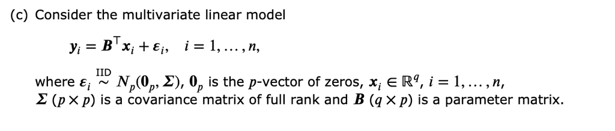

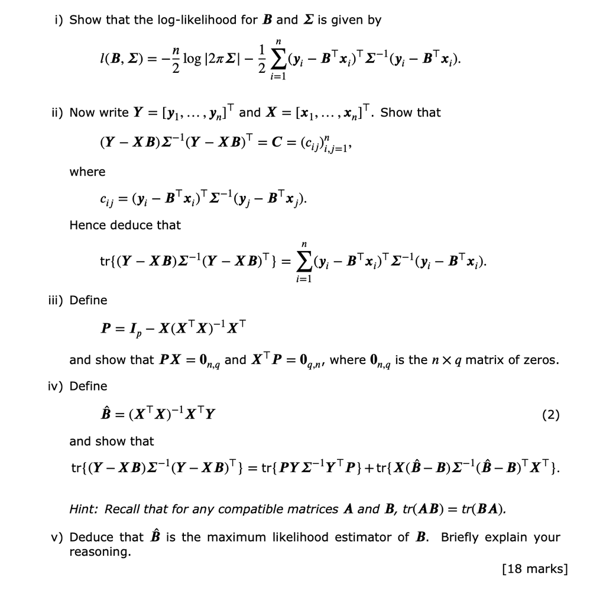

**Solution**

1. Under the model, the distribution of $\mathbf y_i$ given $\mathbf x_i$ is $N_p(\mathbf B^\top \mathbf x_i, \boldsymbol{\Sigma})$ which has pdf
   $$f(\mathbf y_i| \mathbf x_i) = \frac{1}{\sqrt{|2\pi \boldsymbol{\Sigma}|}}\exp\left(- \frac{1}{2}(\mathbf y_i-\mathbf B^\top \mathbf x_i)^\top \boldsymbol{\Sigma}^{-1}(\mathbf y_i - \mathbf B^\top \mathbf x_i)\right)$$
   The likelihood is therefore
   $$L(\mathbf B, \boldsymbol{\Sigma}) = \frac{1}{|2\pi \boldsymbol{\Sigma}|^{n/2}}\exp\left(-\sum_{i=1}^n \frac{1}{2}(\mathbf y_i-\mathbf B^\top \mathbf x_i)^\top \boldsymbol{\Sigma}^{-1}(\mathbf y_i - \mathbf B^\top \mathbf x_i)\right)$$
   and the log-likelihood is
   $$\ell(\mathbf B, \boldsymbol{\Sigma}) = - \frac{n}{2}\log |2\pi \boldsymbol{\Sigma}| -\sum_{i=1}^n \frac{1}{2}(\mathbf y_i-\mathbf B^\top \mathbf x_i)^\top \boldsymbol{\Sigma}^{-1}(\mathbf y_i - \mathbf B^\top \mathbf x_i)$$
2. This is easy to see once we expand the matrix-matrix product
   $$\begin{align*}
   (\mathbf Y- &\mathbf X\mathbf B) \boldsymbol{\Sigma}^{-1}(\mathbf Y-\mathbf X\mathbf B)^\top\\
   &=
   \begin{pmatrix}
   -& (\mathbf y_1 - \mathbf B^\top \mathbf x_1)^\top &-\\
   &\vdots&\\
   -& (\mathbf y_n - \mathbf B^\top \mathbf x_n)^\top&-
   \end{pmatrix} \boldsymbol{\Sigma}^{-1}\begin{pmatrix}
   | & &|\\
   \mathbf y_1 - \mathbf B^\top \mathbf x_1 & \cdots&\mathbf y_n - \mathbf B^\top \mathbf x_n\\
   | & &|
   \end{pmatrix}\\
   &=C=\{c_{ij}\}_{i,j=1}^n
   \end{align*}$$
   where
   $$c_{ij}= (\mathbf y_i - \mathbf B^\top \mathbf x_i)^\top \boldsymbol{\Sigma}^{-1}(\mathbf y_j - \mathbf B^\top \mathbf x_j)$$

Hence
$$\operatorname{tr}\left\{(\mathbf Y- \mathbf X\mathbf B) \boldsymbol{\Sigma}^{-1}(\mathbf Y-\mathbf X\mathbf B)^\top\right\}= \operatorname{tr}(C)=\sum_{i=1}^n (\mathbf y_i - \mathbf B^\top \mathbf x_i)^\top \boldsymbol{\Sigma}^{-1}(\mathbf y_i - \mathbf B^\top \mathbf x_i)$$
iii.
$$PX=(I-X(X^\top X)^{-1} X^\top)X = X -X=0$$
and $X^\top P= (PX)^\top=0$.

4. $$\begin{align*}
   \operatorname{tr}\{ (\mathbf Y-\mathbf X\mathbf B) \boldsymbol{\Sigma}^{-1} (\mathbf Y-\mathbf X\mathbf B)^\top\}=\operatorname{tr}\{ (\mathbf Y-\mathbf X\hat{\mathbf B}+\mathbf X\hat{\mathbf B}-\mathbf X\mathbf B) \boldsymbol{\Sigma}^{-1} (\mathbf Y-\mathbf X\hat{\mathbf B}+\mathbf X\hat{\mathbf B}-\mathbf X\mathbf B)^\top\}\end{align*}$$
   But note that $\mathbf P\mathbf Y= \mathbf Y-\mathbf X\hat{\mathbf B}$ and so
   $$\begin{align*}
   \operatorname{tr}\{ (\mathbf Y-\mathbf X\mathbf B) \boldsymbol{\Sigma}^{-1} (\mathbf Y-\mathbf X\mathbf B)^\top\} &=
   \operatorname{tr}\{ (\mathbf P\mathbf Y-\mathbf X(\hat{\mathbf B}-\mathbf B)) \boldsymbol{\Sigma}^{-1} (\mathbf P\mathbf Y-\mathbf X(\hat{\mathbf B}-\mathbf B))^\top\}\\
   &=
   \operatorname{tr}\{ \boldsymbol{\Sigma}^{-1} (\mathbf P\mathbf Y-\mathbf X(\hat{\mathbf B}-\mathbf B))^\top(\mathbf P\mathbf Y-\mathbf X(\hat{\mathbf B}-\mathbf B))\}\\
   &=\operatorname{tr}\{ \boldsymbol{\Sigma}^{-1} (\mathbf Y^\top \mathbf P\mathbf P\mathbf Y- (\mathbf X(\hat{\mathbf B}-\mathbf B))^\top (\mathbf X(\hat{\mathbf B}-\mathbf B)))\}\\
   &=\operatorname{tr}\{\mathbf P\mathbf Y\boldsymbol{\Sigma}^{-1}\mathbf Y^\top \mathbf P\}+\operatorname{tr}\{(\mathbf X(\hat{\mathbf B}-\mathbf B))\boldsymbol{\Sigma}^{-1} (\mathbf X(\hat{\mathbf B}-\mathbf B))^\top \}
   \end{align*}$$
   as required, where we have used result iii) and that $\operatorname{tr}(AB)=\operatorname{tr}(BA)$.
5. From part iv) we can see that maximizing the log-likelihood is equivalent to minimizing
   $$\operatorname{tr}\{(\mathbf X(\hat{\mathbf B}-\mathbf B))\boldsymbol{\Sigma}^{-1} (\mathbf X(\hat{\mathbf B}-\mathbf B))^\top$$

But if we consider any vector $\mathbf a$, we can see that
$$\mathbf a^\top(\mathbf X(\hat{\mathbf B}-\mathbf B))\boldsymbol{\Sigma}^{-1} (\mathbf X(\hat{\mathbf B}-\mathbf B)\mathbf a=\mathbf b^\top \boldsymbol{\Sigma}^{-1}\mathbf b$$
where $\mathbf b=(\mathbf X(\hat{\mathbf B}-\mathbf B)\mathbf a$. We know that $\boldsymbol{\Sigma}$ is positive definite (it is of full rank), and so $\boldsymbol{\Sigma}$ is positive definite. Hence

$$\mathbf b^\top \boldsymbol{\Sigma}^{-1}\mathbf b\geq 0$$
Hence $(\mathbf X(\hat{\mathbf B}-\mathbf B))\boldsymbol{\Sigma}^{-1} (\mathbf X(\hat{\mathbf B}-\mathbf B))^\top$ is positive definite giving that

$$\operatorname{tr}\{(\mathbf X(\hat{\mathbf B}-\mathbf B))\boldsymbol{\Sigma}^{-1} (\mathbf X(\hat{\mathbf B}-\mathbf B))^\top\geq 0.$$

The minimum (i.e. zero) is achieved at $\mathbf B=\hat{\mathbf B}$, so $\hat{\mathbf B}$ must be the MLE.